# MAGeCK Count Report

Author: Wei Li, weililab.org

## Parameters

comparison_name is the prefix of your output file, defined by the “-n” parameter in your “mageck test” command. The system will look for the following files to generate this report:

- comparison_name.countsummary.txt
- comparison_name.count_normalized.txt
- comparison_name.log

```r
# define the comparison_name here; for example,
# comparison_name='demo'
comparison_name='vorinostat'
```

## Preprocessing

Reading input files. If any of these files are problematic, an error message will be shown below.

```r
cstable=read.table(count_summary_file,header = T,as.is = T)
nc_table=read.table(normalized_cnt_file,header = T,as.is = T)
```

## Summary

The summary of the count command is as follows.

Count command summary

| File | Label | Reads | Mapped | Percentage | TotalsgRNAs | Zerocounts | GiniIndex |
| --- | --- | --- | --- | --- | --- | --- | --- |
| raw_data/library_sequencing/chrom_modulators/5.0.1.20.604/fastq_raw/2171_CRISPR_CM5_Plasmid.fastq | LIB | 4171178 | 3384542 | 0.8114 | 12434 | 20 | 0.06033 |
| raw_data/reads_vorinostat_screen/2546_CRISPR_CM_DMSO1.fastq | DMSO1 | 1100545 | 818164 | 0.7434 | 12434 | 195 | 0.16680 |
| raw_data/reads_vorinostat_screen/2547_CRISPR_CM_DMSO2.fastq | DMSO2 | 1988853 | 1540808 | 0.7747 | 12434 | 71 | 0.10720 |
| raw_data/reads_vorinostat_screen/2548_CRISPR_CM_Vorinostat1.fastq | V1 | 2868072 | 2203415 | 0.7683 | 12434 | 97 | 0.10930 |
| raw_data/reads_vorinostat_screen/2549_CRISPR_CM_Vorinostat2.fastq | V2 | 3039906 | 2368991 | 0.7793 | 12434 | 76 | 0.11070 |

The meanings of the columns are as follows.

- File: The filename of fastq file;
- Label: Assigned label;
- Reads: The total read count in the fastq file;
- Mapped: Reads that can be mapped to gRNA library;
- Percentage: The percentage of mapped reads;
- TotalsgRNAs: The number of sgRNAs in the library;
- ZeroCounts: The number of sgRNA with 0 read counts;
- GiniIndex: The Gini Index of the read count distribution. Gini index can be used to measure the evenness of the read counts, and a smaller value means a more even distribution of the read counts.

If –day0label and –gmt-file options are provided, the following metrics will display the degree of negative selections of essential genes (provided by –gmt-file).

Count command summary

| File | Label | NegSelQC | NegSelQCPval | NegSelQCPvalPermutation | NegSelQCPvalPermutationFDR | NegSelQCGene |
| --- | --- | --- | --- | --- | --- | --- |
| raw_data/library_sequencing/chrom_modulators/5.0.1.20.604/fastq_raw/2171_CRISPR_CM5_Plasmid.fastq | LIB | 0 | 1 | 1 | 1 | 0 |
| raw_data/reads_vorinostat_screen/2546_CRISPR_CM_DMSO1.fastq | DMSO1 | 0 | 1 | 1 | 1 | 0 |
| raw_data/reads_vorinostat_screen/2547_CRISPR_CM_DMSO2.fastq | DMSO2 | 0 | 1 | 1 | 1 | 0 |
| raw_data/reads_vorinostat_screen/2548_CRISPR_CM_Vorinostat1.fastq | V1 | 0 | 1 | 1 | 1 | 0 |
| raw_data/reads_vorinostat_screen/2549_CRISPR_CM_Vorinostat2.fastq | V2 | 0 | 1 | 1 | 1 | 0 |

The meanings of the columns are as follows.

- NegSelQC: the enrichment score (ES) of essential genes in the negative selection list. The score is calculated using GSEA;
- NegSelQCPval: the associated p value of the enrichment score;
- NegSelQCPvalPermutation: the permutated p value of the enrichment score;
- NegSelQCPvalPermutationFDR: the adjusted permutated p value;
- NegSelQCGene: the number of genes used for the analysis.

## Normalized read count distribution of all samples

The following figure shows the distribution of median-normalized read counts in all samples.

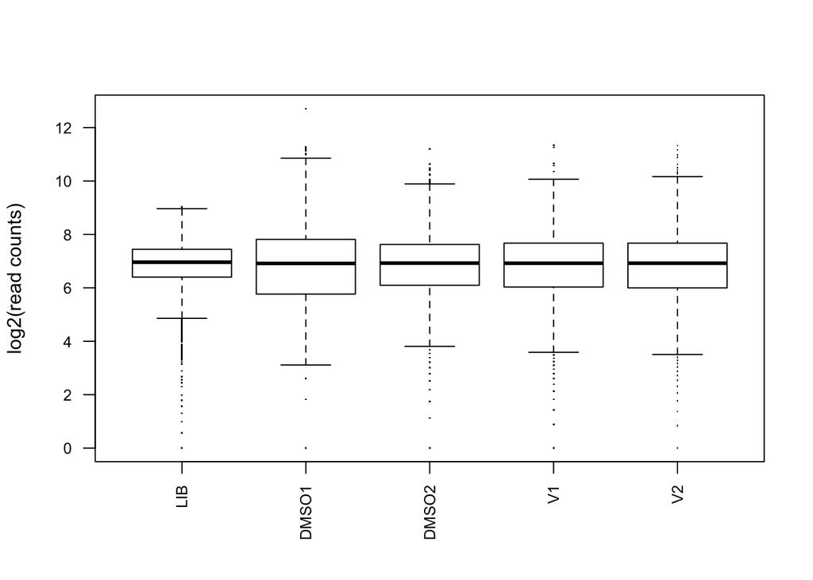

The following figure shows the histogram of median-normalized read counts in all samples.

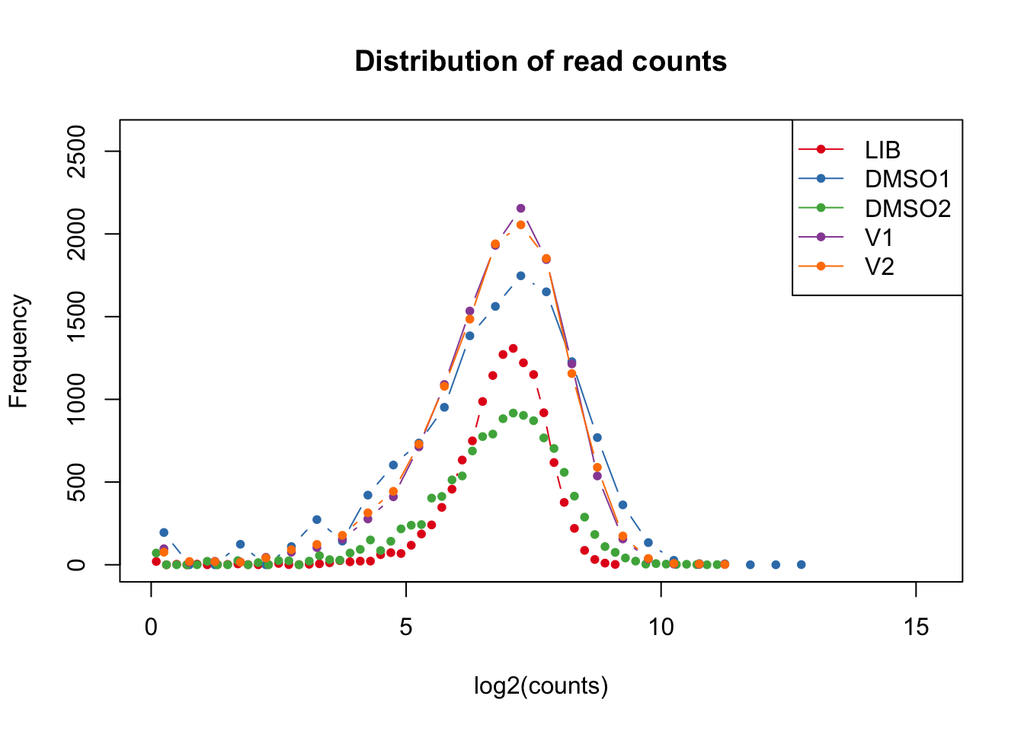

## Principle Component Analysis

The following figure shows the first 2 principle components (PCs) from the Principle Component Analysis (PCA), and the percentage of variances explained by the top PCs.

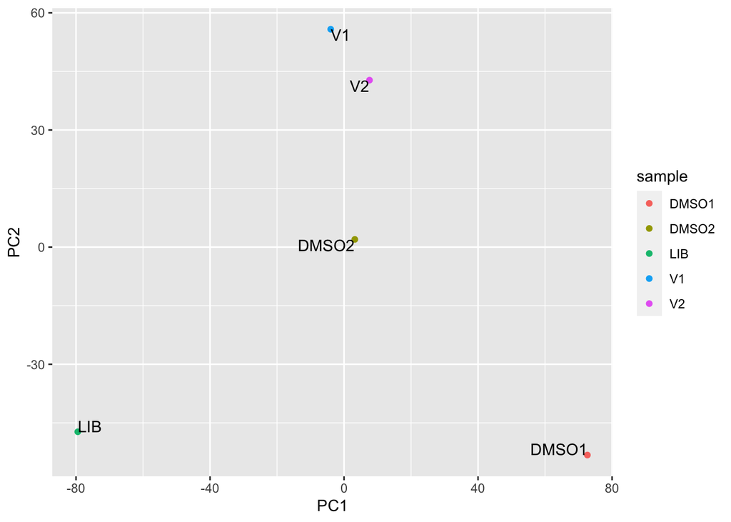

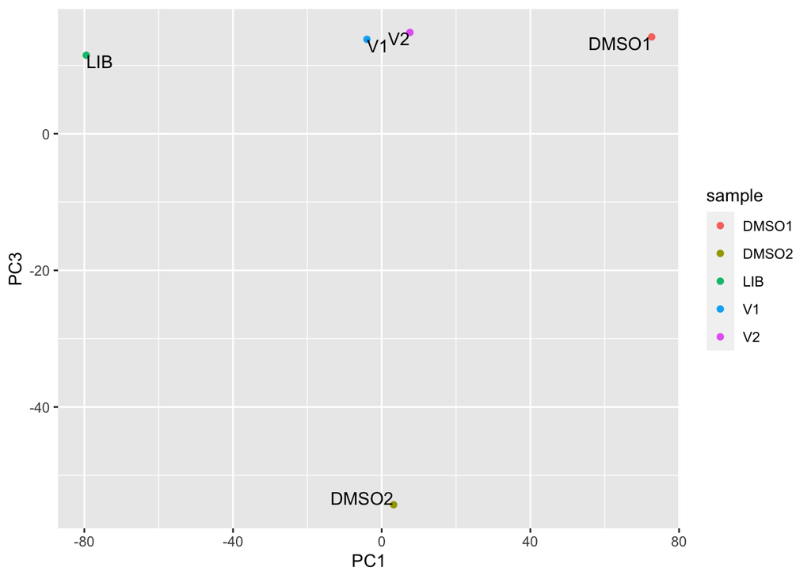

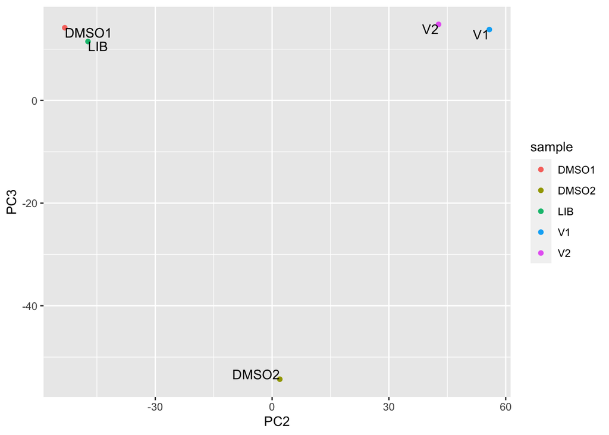

The variance of the PCs

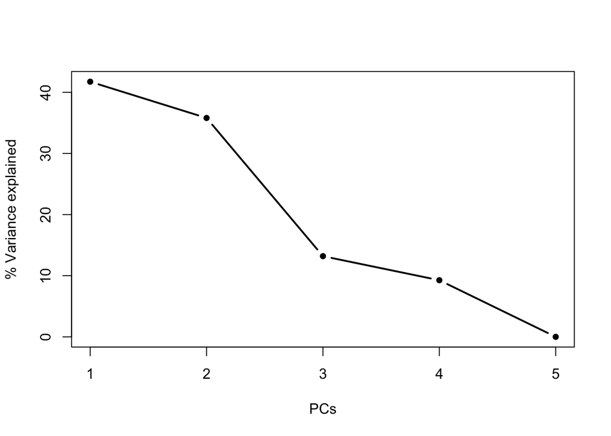

## Sample clustering

The following figure shows the sample clustering result.

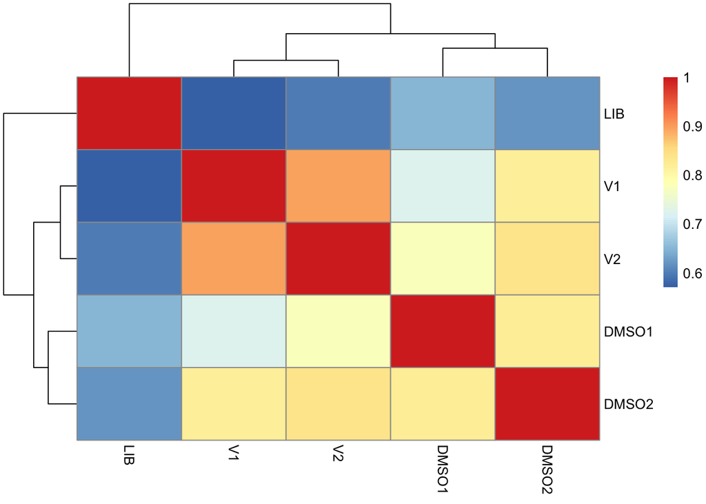